# Child Blood Lead Levels Nationally and in Philadelphia

BMIN503/EPID600 Final Project

Author

Ashley Trocle

## 1 Overview

This project aims to explore current historical trends of childhood lead exposures. To understand this issue, data will be summarized and analyzed at national and local (Philadelphia) levels, utilizing the National Health and Nutrition Examination Survey (NHANES), the American Community Survey (ASC), the EPA’s Environmental Justice Indices, and OpenDataPhilly.Throughout this project, I consulted with three Penn Professors: Dr Cheryl Bettigole, the former health commissioner of Philadelphia, Dr Amin Chen, an environmental epidemiologist, and Dr John Holmes, a social epidemiologist. They provided insights on the availability and interpretation of data, important historical contexts, and key policy knowledge.

Materials for this project can be found here: [GitHub Repository](https://github.com/atrocle/BMIN503_Final_Project_Trocle)

## 2 Introduction

### 2.1 The Problem

Exposure to elevated lead levels during childhood is a critical environmental and public health issue. Lead is a neuro-toxin that impacts neurological and behavioral development in children. Measured most commonly via blood lead levels, there is no safe level of lead exposure in children. Even low levels of lead exposure during developmental stages can lead to lifelong adverse effects on cognitive function and attention.

A primary source of exposure for young children is deteriorating lead based paint, which is still present in many homes despite a national ban in 1978. Children commonly ingest paint chips or paint dust. Both acute and chronic exposure to lead can be dangerous. Elevated blood lead levels continue to disproportionately affect marginalized communities, especially low-income and minority groups who often live in older, non-remidiated housing. Addressing lead exposure is key to addressing health disparities nationally and in our communities.

### 2.2 The Policies

A number of federal, state and local policies have dramatically reduces the rates of lead exposures in the past 50 years.

National:

- 1974: Safe Drinking Water Act
- 1978: Lead based paints were banned in residences
- 1999: Lead Safe Housing Rule
- 2021: Biden-Harris Lead Pipe and Paint Action Plan

Local:

- 2011: Philadelphia Lead Paint Disclosure Law
- 2019: Expansion of the 2011 law to include all rental properties, not only those with children

### 2.3 This Project

Using data from the NHANES, ASC, OpenDataPhilly, this project sought to understand the relationship between lead exposure and various demographic, socioeconomic and neighborhood characteristics.

This project takes an interdisciplinary approach to better understand lead exposure issues at national, state and local levels. The project integrates social epidemiology, environmental health, public health and policy analysis to address the complex nature of issues that contribute to lead exposure and the significant impact it can have on children.

## 3 Methods

After loading the necessary packages, the data is uploaded and cleaned below.

### 3.1 Loading Packages

```r
#Load Packages
library(nhanesA)
library(tidyverse)
library(haven)
library(dplyr)
library(ggplot2)
library(survey)
library(sf)
library(tidycensus)
library(ggspatial)
library(leaflet)
library(RColorBrewer)
library(spdep)
```

### 3.2 Loading and Cleaning Data

```r
#import NHANES_L (2021-2023): Demographics, Income and Phlebotomy modules
varlist <- c("DEMO", "PBCD", "INQ")
varlist_years <- paste0(rep(varlist, each = 2), c("_I", "_L"))

#Load everything from varlist_years in nhanes as a list)
list_all <- sapply(varlist_years, function(x) {data.frame(nhanes(x))})

#Create a data.frame for each module
for(i in 1:length(list_all)) {
  assign(names(list_all)[i], list_all[[i]])
}

#Combine modules from each year into one larger data.frame
for (i in 1:length(varlist)) {
  assign(varlist[i], plyr::rbind.fill(mget(grep(varlist[i], ls(), value = T))))
}
rm(list = grep("_[IL]", ls(), value = T))

#Create a single data.frame that combines all modules
nhanes.data <- full_join(get(varlist[1]), get(varlist[2]), by = "SEQN")

#Create a single data.frame that combines all modules
for (i in 3:length(varlist)){
  nhanes.data <- full_join(nhanes.data, get(varlist[i]), by = "SEQN")
}

rm(list = ls()[-which(ls() == "nhanes.data")])

names(nhanes.data) #confirm loaded correctly
```

```
 [1] "SEQN"     "SDDSRVYR" "RIDSTATR" "RIAGENDR" "RIDAGEYR" "RIDAGEMN"
 [7] "RIDRETH1" "RIDRETH3" "RIDEXMON" "RIDEXAGM" "DMQMILIZ" "DMQADFC"
[13] "DMDBORN4" "DMDCITZN" "DMDYRSUS" "DMDEDUC3" "DMDEDUC2" "DMDMARTL"
[19] "RIDEXPRG" "SIALANG"  "SIAPROXY" "SIAINTRP" "FIALANG"  "FIAPROXY"
[25] "FIAINTRP" "MIALANG"  "MIAPROXY" "MIAINTRP" "AIALANGA" "DMDHHSIZ"
[31] "DMDFMSIZ" "DMDHHSZA" "DMDHHSZB" "DMDHHSZE" "DMDHRGND" "DMDHRAGE"
[37] "DMDHRBR4" "DMDHREDU" "DMDHRMAR" "DMDHSEDU" "WTINT2YR" "WTMEC2YR"
[43] "SDMVPSU"  "SDMVSTRA" "INDHHIN2" "INDFMIN2" "INDFMPIR" "DMDYRUSR"
[49] "DMDMARTZ" "DMDHRAGZ" "DMDHREDZ" "DMDHRMAZ" "DMDHSEDZ" "WTSH2YR"
[55] "LBXBPB"   "LBDBPBSI" "LBDBPBLC" "LBXBCD"   "LBDBCDSI" "LBDBCDLC"
[61] "LBXTHG"   "LBDTHGSI" "LBDTHGLC" "LBXBSE"   "LBDBSESI" "LBDBSELC"
[67] "LBXBMN"   "LBDBMNSI" "LBDBMNLC" "WTPH2YR"  "INQ020"   "INQ012"
[73] "INQ030"   "INQ060"   "INQ080"   "INQ090"   "INQ132"   "INQ140"
[79] "INQ150"   "IND235"   "INDFMMPI" "INDFMMPC" "INQ300"   "IND310"
[85] "INQ320"
```

```r
#Limit the dataset to the necessary variables and limit to children under 5
nhanes.data.sub <- nhanes.data |>
  select( id = SEQN, survey = SDDSRVYR, gender = RIAGENDR, age = RIDAGEYR, race3 = RIDRETH3, birth_country= DMDBORN4, timeUS = DMDYRUSR, income_poverty = INDFMPIR,  bll=LBXBPB, blldetected =LBDBPBLC, poverty_level= INDFMMPC, IP_ratio= INDFMPIR, cash= IND310, interview_weight=WTINT2YR, MEC_weight =WTMEC2YR, samplingunit = SDMVPSU,strata = SDMVSTRA) |>
   mutate(gender = factor(case_when(
      gender == "Male" ~ 0,
      gender == "Female" ~ 1),
    levels = c(0, 1),
    labels = c("Male", "Female")))|>
   mutate(survey = factor(case_when(
      survey == 9 ~ 0,
      survey == 12 ~ 1
    ), levels = c(0, 1),
    labels = c("2015-2016", "2021-2023")))|>
  filter(age <6)|>
  mutate(agecat = case_when(
      age < 2 ~ "1-<2",
      age >= 2 & age < 3 ~ "2-<3",
      age >= 3 & age < 4 ~ "3-<4",
      age >= 4 & age < 5 ~ "4-<5",
      age >= 5 & age < 6 ~ "5-<6"
    )
  )

#planning to relevel or mutate the other variables
head(nhanes.data.sub)
```

```
     id    survey gender age              race3
1 83739 2015-2016   Male   4 Non-Hispanic White
2 83740 2015-2016   Male   1     Other Hispanic
3 83746 2015-2016 Female   4 Non-Hispanic Asian
4 83748 2015-2016   Male   3 Non-Hispanic Black
5 83760 2015-2016 Female   3 Non-Hispanic Black
6 83763 2015-2016 Female   2     Other Hispanic
                           birth_country timeUS income_poverty  bll
1 Born in 50 US states or Washington, DC   <NA>           4.22 0.29
2 Born in 50 US states or Washington, DC   <NA>             NA   NA
3                                 Others   <NA>             NA   NA
4 Born in 50 US states or Washington, DC   <NA>           0.94   NA
5 Born in 50 US states or Washington, DC   <NA>           1.10 0.44
6 Born in 50 US states or Washington, DC   <NA>           1.94   NA
                      blldetected                       poverty_level IP_ratio
1 At or above the detection limit  Monthly poverty level index > 1.85     4.22
2                            <NA>                                <NA>       NA
3                            <NA>  Monthly poverty level index > 1.85       NA
4                            <NA> Monthly poverty level index <= 1.30     0.94
5 At or above the detection limit Monthly poverty level index <= 1.30     1.10
6                            <NA>  Monthly poverty level index > 1.85     1.94
         cash interview_weight MEC_weight samplingunit strata agecat
1        <NA>        44749.890  46173.307            2    124   4-<5
2        <NA>         9891.944  10963.314            1    119   1-<2
3        <NA>        10998.012  11273.998            2    129   4-<5
4 $0 - $3,000        10988.317  11184.295            2    131   3-<4
5     Refused         8862.399   8919.396            2    126   3-<4
6 $0 - $3,000        17174.314  18158.810            1    127   2-<3
```

```r
#Weighting data (still working on how to use this in the Results)
nhanes.data.sub$adjusted_weight <- nhanes.data.sub$MEC_weight / 2

nhanes_design <- svydesign(
  id = ~samplingunit,
  strata = ~strata,
  weights = ~adjusted_weight,
  data = nhanes.data.sub,
  nest = TRUE
)

summary(nhanes_design)
```

```
Stratified 1 - level Cluster Sampling design (with replacement)
With (60) clusters.
svydesign(id = ~samplingunit, strata = ~strata, weights = ~adjusted_weight,
    data = nhanes.data.sub, nest = TRUE)
Probabilities:
     Min.   1st Qu.    Median      Mean   3rd Qu.      Max.
2.001e-05 8.900e-05 1.523e-04       Inf 2.783e-04       Inf
Stratum Sizes:
           119 120 121 122 123 124 125 126 127 128 129 130 131 132 133 173 174
obs         58 142 117  99  91  81  94 142  91  97  91 157 149 134  61  70 102
design.PSU   2   2   2   2   2   2   2   2   2   2   2   2   2   2   2   2   2
actual.PSU   2   2   2   2   2   2   2   2   2   2   2   2   2   2   2   2   2
           175 176 177 178 179 180 181 182 183 184 185 186 187
obs         71  81  63 106  81  73  77  96  79 102  75  71  90
design.PSU   2   2   2   2   2   2   2   2   2   2   2   2   2
actual.PSU   2   2   2   2   2   2   2   2   2   2   2   2   2
Data variables:
 [1] "id"               "survey"           "gender"           "age"
 [5] "race3"            "birth_country"    "timeUS"           "income_poverty"
 [9] "bll"              "blldetected"      "poverty_level"    "IP_ratio"
[13] "cash"             "interview_weight" "MEC_weight"       "samplingunit"
[17] "strata"           "agecat"           "adjusted_weight"
```

```r
#Create a Dataset with BLL values for those < 18 years of age
nhanes.data.bll <-nhanes.data.sub|>
  filter (!is.na(bll)) |>
  mutate( elevated.bll = case_when(
       bll < 0.5 ~ "not elevated",
       bll >= 0.5 ~ "elevated"),
       elevated.bll = factor(elevated.bll,
                             levels = c("not elevated", "elevated")))

head(nhanes.data.bll)
```

```
     id    survey gender age                               race3
1 83739 2015-2016   Male   4                  Non-Hispanic White
2 83760 2015-2016 Female   3                  Non-Hispanic Black
3 83772 2015-2016 Female   2 Other Race - Including Multi-Racial
4 83780 2015-2016   Male   4                    Mexican American
5 83792 2015-2016 Female   3                    Mexican American
6 83797 2015-2016 Female   1                      Other Hispanic
                           birth_country timeUS income_poverty  bll
1 Born in 50 US states or Washington, DC   <NA>           4.22 0.29
2 Born in 50 US states or Washington, DC   <NA>           1.10 0.44
3 Born in 50 US states or Washington, DC   <NA>           1.25 0.55
4 Born in 50 US states or Washington, DC   <NA>           2.82 0.96
5 Born in 50 US states or Washington, DC   <NA>           2.51 1.61
6 Born in 50 US states or Washington, DC   <NA>           4.22 0.49
                      blldetected                       poverty_level IP_ratio
```

[output cut: 20 more lines]

```r
table(nhanes.data.bll$survey, nhanes.data.bll$elevated.bll)
```

```
            not elevated elevated
  2015-2016          186      604
  2021-2023          145      156
```

```r
#update survey design with elevated bll variables
#nhanes_design_bll <- update(nhanes_design, elevated.bll = nhanes.data.bll$elevated.bll)
```

```r
#revising which variables collecting from the ACS data to use in the analysis -> will use this for mapping and regression

#National ACS Data by County
acs.data.national<- get_acs(geography= "county",
                   year= 2022,
                   variables = c("B25034_002E", "B25034_003E", "B25034_004E",
"B25034_005E", "B25034_006E", "B25034_007E","B25034_008E","B25034_009", "B25034_010E","B25034_011E"),
               output = "wide")
#Philadelphia ACS Data by Tract
acs.data.phl<- get_acs(geography= "tract",
                   year= 2022,
                   variables = c("B25034_002E", "B25034_003E", "B25034_004E",
"B25034_005E", "B25034_006E", "B25034_007E","B25034_008E","B25034_009", "B25034_010E","B25034_011E"),
                  output = "wide",
                  state="PA",
                  county="Philadelphia")
```

**OpenDataPhilly Lead Data:** The dataset includes the number of children screened for elevated blood lead levels (BLL) defined as >5ug/dL, incidence of children with elevated BLL, and percent screened that with elevated BLL by census tract from 2013-2015. Values are missing where there are less than 6 observations for confidentiality purposes.

```r
#OpenDataPhilly Data
phllead <- read.csv("C:\\Users\\atrocle\\Documents\\.EPID 6000 Data Science\\Assignments\\Final Project\\opendataphl_lead_tract.csv", header = TRUE)
head(phllead) #confirm loading properly
```

```
  census_tract data_redacted num_bll_5plus num_screen perc_5plus
1   4.2101e+10         false             0        100          0
2   4.2101e+10          true            NA        109         NA
3   4.2101e+10          true            NA        110         NA
4   4.2101e+10          true            NA         61         NA
5   4.2101e+10         false             0         41          0
6   4.2101e+10          true            NA         49         NA
```

```r
#Load Tract Polygon data
philly.tracts <- read_rds("https://raw.githubusercontent.com/HimesGroup/BMIN503/master/DataFiles/philly.tracts.2020.rds")
names(philly.tracts)
```

```
 [1] "STATEFP"  "COUNTYFP" "TRACTCE"  "GEOID"    "NAME"     "NAMELSAD"
 [7] "MTFCC"    "FUNCSTAT" "ALAND"    "AWATER"   "INTPTLAT" "INTPTLON"
[13] "geometry"
```

```r
#Combine spatial with lead
phllead <- phllead |>
  rename(GEOID = census_tract) |>
  mutate(GEOID = as.character(GEOID))

phllead_geo <- philly.tracts |>
  left_join(phllead, by = "GEOID")
```

```r
ejscreen <- read.csv("C:\\Users\\atrocle\\Documents\\.EPID 6000 Data Science\\Assignments\\Final Project\\EJScreen_2024_Tract.csv", header = TRUE)
ejscreen_limit <- ejscreen|>
  select( GEOID = ID,
    State = STATE_NAME,
    County_name = CNTY_NAME,
    Region = REGION,
    Demographic_Index = DEMOGIDX_2,
    Supplemental_Demographic_Index = DEMOGIDX_5,
    Percent_POC = PEOPCOLORPCT,
    Percent_Low_Income = LOWINCPCT,
    Percent_Unemployed = UNEMPPCT,
    Percent_Disabled = DISABILITYPCT,
    Percent_Limited_English = LINGISOPCT,
    Percent_No_HS_Education = LESSHSPCT,
    Percent_Under5 = UNDER5PCT,
    Percent_Over64 = OVER64PCT,
    Percent_Low_Life_Expectancy = LIFEEXPPCT,
    Lead_Paint_Percent = PRE1960PCT,
    Lead_Paint_EJ_Index = D2_LDPNT,
    Lead_Paint_Supp_Index = D5_LDPNT
  )
ejscreen_phila <- ejscreen_limit|>
  filter(State== "PENNSYLVANIA" & County_name =="Philadelphia County") |>
  mutate(GEOID = as.character(GEOID))

#add to OpenDataPhilly Lead Data
phllead_geo <- phllead_geo |>
  left_join(ejscreen_phila, by = "GEOID")
names(phllead_geo)
```

```
 [1] "STATEFP"                        "COUNTYFP"
 [3] "TRACTCE"                        "GEOID"
 [5] "NAME"                           "NAMELSAD"
 [7] "MTFCC"                          "FUNCSTAT"
 [9] "ALAND"                          "AWATER"
[11] "INTPTLAT"                       "INTPTLON"
[13] "data_redacted"                  "num_bll_5plus"
[15] "num_screen"                     "perc_5plus"
[17] "State"                          "County_name"
[19] "Region"                         "Demographic_Index"
[21] "Supplemental_Demographic_Index" "Percent_POC"
[23] "Percent_Low_Income"             "Percent_Unemployed"
[25] "Percent_Disabled"               "Percent_Limited_English"
[27] "Percent_No_HS_Education"        "Percent_Under5"
[29] "Percent_Over64"                 "Percent_Low_Life_Expectancy"
[31] "Lead_Paint_Percent"             "Lead_Paint_EJ_Index"
[33] "Lead_Paint_Supp_Index"          "geometry"
```

**Themes**: Themes for maps are loaded.

```r
myPalette <- colorRampPalette(brewer.pal(9, "BuPu"))  #
map_theme <- function() {
  theme_minimal() +
  theme(axis.line = element_blank(),
        axis.text = element_blank(),
        axis.title = element_blank(),
        panel.grid = element_line(color = "white"),
        legend.key.size = unit(0.8, "cm"),
        legend.text = element_text(size = 12),
        legend.title = element_text(size = 12))
}
```

## 4 Results

### 4.1 National:

Using the national data, we will evaluate trends over time.

#### 4.1.1 Exploratory Analysis of BLLs in Children

Elevated Blood Lead Levels by Year and Gender using NHANES Data

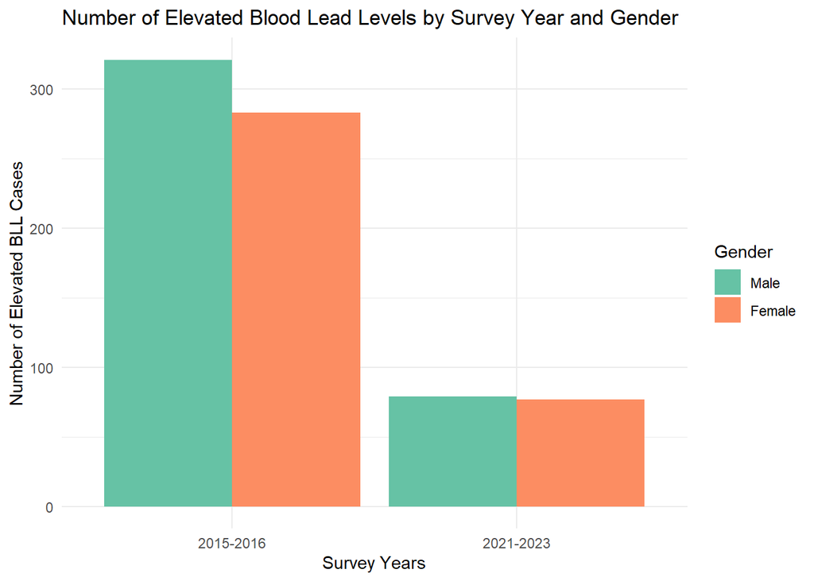

```r
elevatedgender <- nhanes.data.bll |>
  filter(elevated.bll == "elevated") |>
  group_by(survey, gender) |>
  summarize(count = n(), .groups = 'drop')

ggplot(elevatedgender, aes(x = factor(survey), y = count, fill = as.factor(gender))) +
  geom_bar(stat = "identity", position = "dodge") +
  labs(
    title = "Number of Elevated Blood Lead Levels by Survey Year and Gender",
    x = "Survey Years",
    y = "Number of Elevated BLL Cases",
    fill = "Gender"
  ) +
   scale_fill_brewer(palette = "Set2") +
  theme_minimal()
```

Elevated Blood Lead Levels by Year and Race using NHANES Data

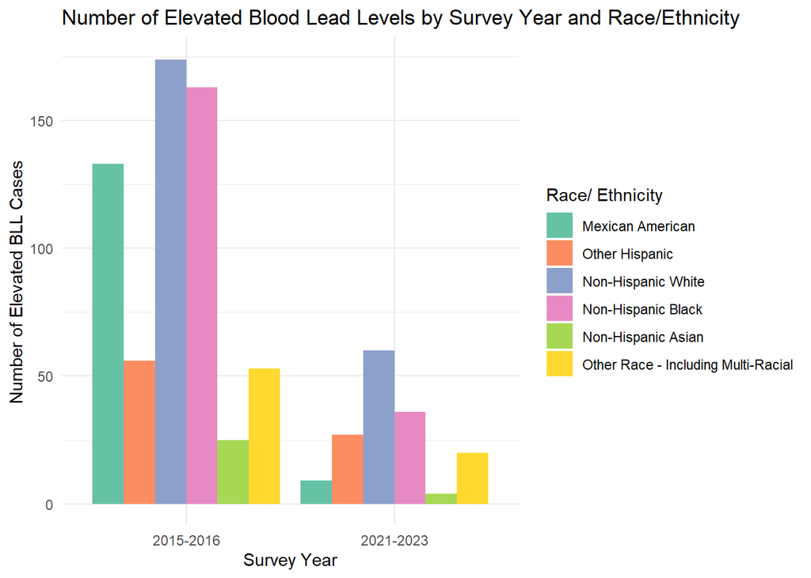

```r
elevatedrace <- nhanes.data.bll |>
  filter(elevated.bll == "elevated") |>
  group_by(survey, race3) |>
  summarize(count = n(), .groups = 'drop')

ggplot(elevatedrace, aes(x = factor(survey), y = count, fill = as.factor(race3))) +
  geom_bar(stat = "identity", position = "dodge") +
  labs(
    title = "Number of Elevated Blood Lead Levels by Survey Year and Race/Ethnicity",
    x = "Survey Year",
    y = "Number of Elevated BLL Cases",
    fill = "Race/ Ethnicity"
  ) +
  scale_fill_brewer(palette = "Set2") +
  theme_minimal()
```

Elevated Blood Lead Levels by Year and Age using NHANES Data

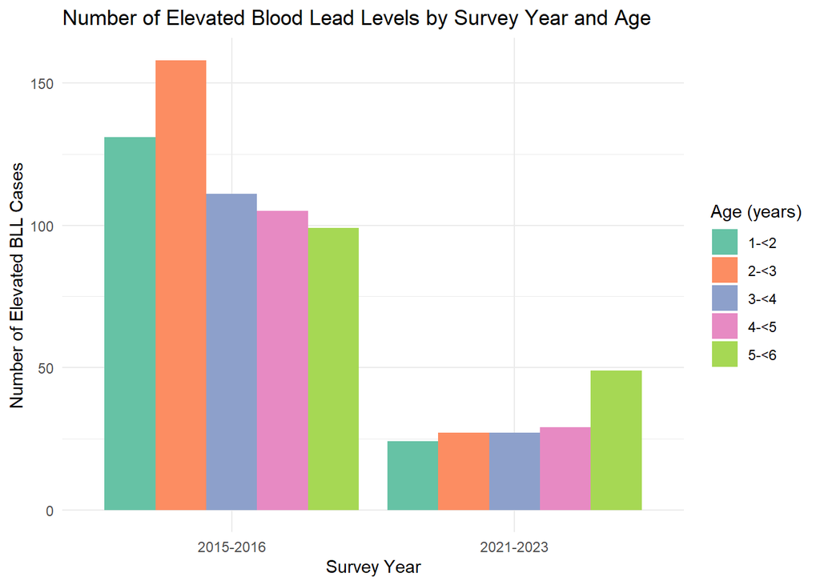

```r
elevatedage <- nhanes.data.bll |>
  filter(elevated.bll == "elevated") |>
  group_by(survey, agecat) |>
  summarize(count = n(), .groups = 'drop')

ggplot(elevatedage, aes(x = factor(survey), y = count, fill = as.factor(agecat))) +
  geom_bar(stat = "identity", position = "dodge") +
  labs(
    title = "Number of Elevated Blood Lead Levels by Survey Year and Age",
    x = "Survey Year",
    y = "Number of Elevated BLL Cases",
    fill = "Age (years)"
  ) +
  scale_fill_brewer(palette = "Set2") +
  theme_minimal()
```

Statistical Analysis (will update for weighted) Logistic Regression:

```r
logisticmodel <- glm(
  elevated.bll ~ gender + age + survey + income_poverty,
  data = nhanes.data.bll,
  family = binomial(link = "logit")
)
summary(logisticmodel)
```

```
Call:
glm(formula = elevated.bll ~ gender + age + survey + income_poverty,
    family = binomial(link = "logit"), data = nhanes.data.bll)

Coefficients:
                Estimate Std. Error z value Pr(>|z|)
(Intercept)      2.21855    0.22681   9.781  < 2e-16 ***
genderFemale    -0.06337    0.14536  -0.436  0.66287
age             -0.16634    0.05235  -3.177  0.00149 **
survey2021-2023 -0.92116    0.15594  -5.907 3.48e-09 ***
income_poverty  -0.27638    0.04661  -5.930 3.03e-09 ***
---
Signif. codes:  0 '***' 0.001 '**' 0.01 '*' 0.05 '.' 0.1 ' ' 1

(Dispersion parameter for binomial family taken to be 1)

    Null deviance: 1226.0  on 989  degrees of freedom
Residual deviance: 1124.6  on 985  degrees of freedom
  (101 observations deleted due to missingness)
AIC: 1134.6

Number of Fisher Scoring iterations: 4
```

Chi-Square

```r
table <- table(nhanes.data.bll$survey, nhanes.data.bll$elevated.bll)
chisq.test(table)
```

```
    Pearson's Chi-squared test with Yates' continuity correction

data:  table
X-squared = 61.394, df = 1, p-value = 4.673e-15
```

### 4.2 Local:

Using data from Philadelphia BLL collection and national survey, we will look view the issue though a local lens.

First, we summarize the data

```r
#Understand how many tracts are redacted
table(phllead_geo$data_redacted)
```

```
false  true
  236   123
```

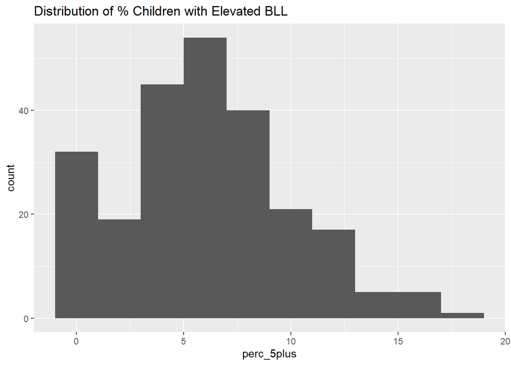

```r
#Histogram of the distribuion of elevated BLL %
ggplot(phllead_geo, aes(x = perc_5plus)) +
  geom_histogram(binwidth = 2) +
  labs(title = "Distribution of % Children with Elevated BLL")
```

Next, we look at a visual of the percent of children screen that had elevated BLLs..

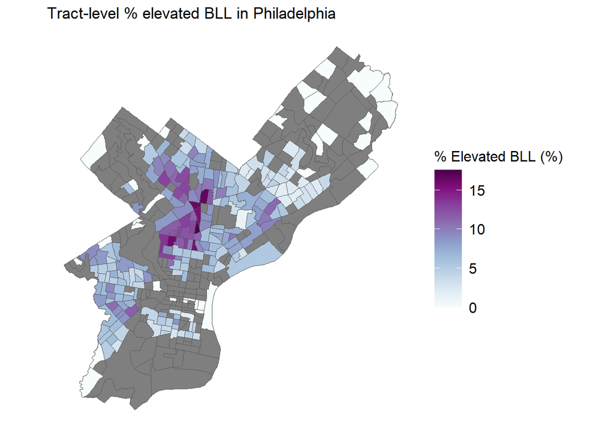

```r
#Static Map of Elevated BLL %
ggplot() +
  geom_sf(data = phllead_geo, aes(fill = perc_5plus))+
   map_theme() +
  ggtitle("Tract-level % elevated BLL in Philadelphia") +
  scale_fill_gradientn(name = "% Elevated BLL (%)",
                    colours = myPalette(100))
```

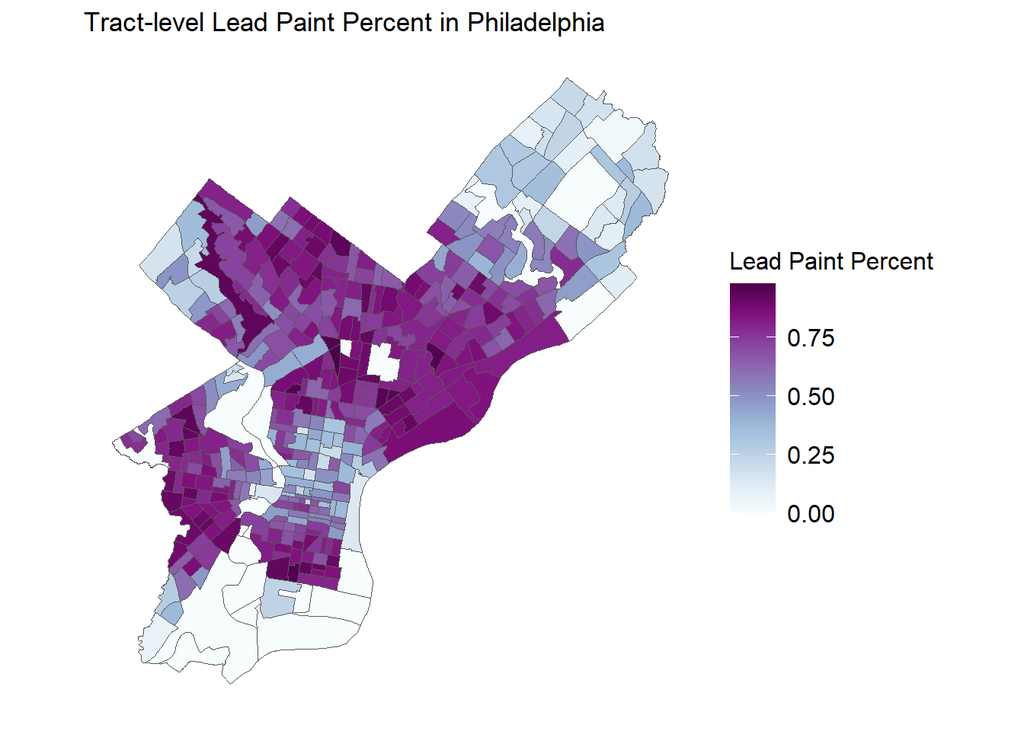

```r
#Static Map of
ggplot() +
  geom_sf(data = phllead_geo, aes(fill = Lead_Paint_Percent)) +
  map_theme() +
  ggtitle("Tract-level Lead Paint Percent in Philadelphia") +  # Update title for clarity
  scale_fill_gradientn(name = "Lead Paint Percent",
                       colours = myPalette(100))
```

```r
#Leaflet Map of multiple Variables
#Change the CRS
phllead_geo2 <- st_transform(phllead_geo, crs = 4326)
#create leaflet map here
```

[output not shown]

We can also look at the if the variables from the EPA Environmental Justice scores are related to the percentage of children with elevated BLL.

```r
#Linear Regression:
lm1 <-lm(perc_5plus ~ Percent_POC + Percent_Low_Income + Lead_Paint_Percent, data = phllead_geo)
summary(lm1)
```

```
Call:
lm(formula = perc_5plus ~ Percent_POC + Percent_Low_Income +
    Lead_Paint_Percent, data = phllead_geo)

Residuals:
    Min      1Q  Median      3Q     Max
-6.1146 -2.3000 -0.4383  1.8221  9.8375

Coefficients:
                   Estimate Std. Error t value Pr(>|t|)
(Intercept)         -2.8696     0.8164  -3.515 0.000528 ***
Percent_POC          4.9247     1.1218   4.390 1.71e-05 ***
Percent_Low_Income   3.1142     1.5043   2.070 0.039525 *
Lead_Paint_Percent   5.0942     1.1096   4.591 7.19e-06 ***
---
Signif. codes:  0 '***' 0.001 '**' 0.01 '*' 0.05 '.' 0.1 ' ' 1

Residual standard error: 3.143 on 235 degrees of freedom
  (169 observations deleted due to missingness)
Multiple R-squared:  0.3653,    Adjusted R-squared:  0.3572
F-statistic: 45.08 on 3 and 235 DF,  p-value: < 2.2e-16
```

```r
# Create a spatial weights matrix
nb <- poly2nb(phllead_geo)
lw <- nb2listw(nb)

# Spatial lag model
lmspat <- lm( perc_5plus~ Percent_POC + Lead_Paint_Percent, data = phllead_geo)
#spreg <- spautolm(perc_5plus~ Percent_POC + Lead_Paint_Percent, data = phllead_geo, listw = lw)
```

## 5 Conclusion

The visualizations and analyses in this project depict current and historical trends in blood lead levels (BLLs) among children in the United States. Despite overall declines in BLLs, there are disparities that remain to be seen, disproportionately affecting marginalized communities. Geographic regions with higher percentages of low-income populations, racial minorities, and older housing show elevated BLLs. These patterns underscore systemic inequities tied to socioeconomic and environmental factors.

The findings call for targeted interventions. Areas with the highest burden of elevated BLLs should be prioritized for lead remediation efforts, such as replacing infrastructure with lead, enforcing regulations, and providing education on lead exposure prevention. By addressing lead exposures in children through these efforts, these initiatives will address long term consequences of exposure to lead and improve the health of children in the long term.

## 6 Acknowledgements

I would like to thank the following faculty members who were consulted on designing and implementing the research question:

- Dr John Holmes
- Dr Aimin Chen
- Dr Cheryl Bettigole